# Exploring the Forest Cover Data

Kevin

Thursday, April 02, 2015

[figure not shown]

We are working on the [forest cover kaggle competition](http://www.kaggle.com/c/forest-cover-type-predictionhttp://www.kaggle.com/c/forest-cover-type-prediction). Our [GitHub repo](https://github.com/mdlerch/forest_cover) contains the testing data which we have split up into a testing set and a training set.

In this challenge, you are given some information about a location and asked to predict which of 7 species of tree is the predominant species. Here are some exploratory plots. I’m using this as a chance to check out some [htmlwidgets](http://htmlwidgets.org/) so be prepared for a lot of different styles of plots.

My basic setup code

```r
knitr::opts_chunk$set(echo = T,
                      message = F,
                      warning = F,
                      tidy = F,
                      fig.height = 6,
                      fig.width = 10,
                      comment = "#>",
                      cache = F,
                      size = "small",
                      results = "asis")
options(show.signif.stars = F,
        digits = 3)
```

## Data

Loading the data. Interestingly, it present both wilderness and soil type in wide format. I’ve had to modify this for most of the plots. This part of the code is not very interesting.

```r
# packages for data manipulation
library(tidyr)   ## to turn data to long format
library(dplyr)   ## for basic data manipulation

# grab right n characters of a string
substrRight <- function(x, n){
  substr(x, nchar(x)-n+1, nchar(x))
}

# data ------------------------------------------------

# load data
dat <- read.csv("data/our_train.csv", header = T, stringsAsFactors = F) %>%
  tbl_df() %>%
  select(-X)
dat
```

```
#> Source: local data frame [9,072 x 56]
#>
#>       Id Elevation Aspect Slope Horizontal_Distance_To_Hydrology
#> 1   6286      2413      2    21                               30
#> 2  14366      3474    127    24                              258
#> 3   6146      2980    330     8                              134
#> 4   6210      2466      0    18                              153
#> 5   8066      3068    195    26                              874
#> 6   7111      2757     22    13                              175
#> 7  14655      2974      4    14                              285
#> 8   8815      3166     49    23                              150
#> 9   2766      2073     98    13                              150
#> 10  8535      2774     98    23                              366
#> ..   ...       ...    ...   ...                              ...
#> Variables not shown: Vertical_Distance_To_Hydrology (int),
#>   Horizontal_Distance_To_Roadways (int), Hillshade_9am (int),
#>   Hillshade_Noon (int), Hillshade_3pm (int),
#>   Horizontal_Distance_To_Fire_Points (int), Wilderness_Area1 (int),
#>   Wilderness_Area2 (int), Wilderness_Area3 (int), Wilderness_Area4 (int),
#>   Soil_Type1 (int), Soil_Type2 (int), Soil_Type3 (int), Soil_Type4 (int),
#>   Soil_Type5 (int), Soil_Type6 (int), Soil_Type7 (int), Soil_Type8 (int),
#>   Soil_Type9 (int), Soil_Type10 (int), Soil_Type11 (int), Soil_Type12
#>   (int), Soil_Type13 (int), Soil_Type14 (int), Soil_Type15 (int),
#>   Soil_Type16 (int), Soil_Type17 (int), Soil_Type18 (int), Soil_Type19
#>   (int), Soil_Type20 (int), Soil_Type21 (int), Soil_Type22 (int),
#>   Soil_Type23 (int), Soil_Type24 (int), Soil_Type25 (int), Soil_Type26
#>   (int), Soil_Type27 (int), Soil_Type28 (int), Soil_Type29 (int),
#>   Soil_Type30 (int), Soil_Type31 (int), Soil_Type32 (int), Soil_Type33
#>   (int), Soil_Type34 (int), Soil_Type35 (int), Soil_Type36 (int),
#>   Soil_Type37 (int), Soil_Type38 (int), Soil_Type39 (int), Soil_Type40
#>   (int), Cover_Type (int)
```

```r
# turn soil column into long format
soil_long <- dat %>%
  gather(Soil, yn, -(Id:Wilderness_Area4), -Cover_Type) %>%
  filter(yn == 1) %>%
  mutate(
    Soil = as.character(Soil),
    Soil = ifelse(nchar(Soil) == 10, substrRight(Soil, 1), substrRight(Soil, 2)),
    Soil = as.numeric(Soil)
  ) %>%
  select(-yn)

# turn wilderness to long format
wild_long <- dat %>%
  gather(Wilderness, yn, -(Id:Horizontal_Distance_To_Fire_Points), -(Soil_Type1:Soil_Type40), -Cover_Type) %>%
  filter(yn == 1) %>%
  mutate(
    Wilderness = Wilderness %>% as.character %>% substrRight(1) %>% as.numeric) %>%
  select(-yn)

# both wild and soil in long formation
all_long <- soil_long %>%
  gather(Wilderness, yn, -(Id:Horizontal_Distance_To_Fire_Points), -Cover_Type, -Soil) %>%
  filter(yn == 1) %>%
  mutate(
    Wilderness = Wilderness %>% as.character %>% substrRight(1) %>% as.numeric) %>%
  select(-yn)
```

## Soil Type

One of the variable that is provided is the type of the soil. This is classified into one of 40 categories. I turned this into long format in a data.frame called `soil_long` in the preceding code chunk. Looking at the ggplot below, there are a couple of things I notice:

1. Not all 40 soils are present (ex. soil 7, soil 15, etc)
2. Some soils are a lot more common than others (looking at you soil 10)
3. It looks like there are typically 3-4 tree species per soil type

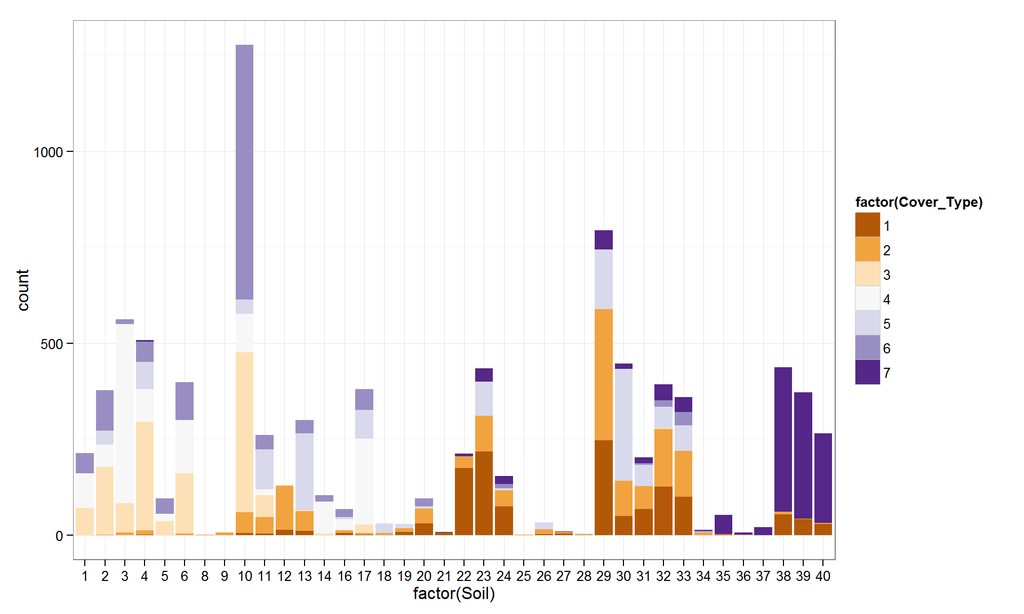

```r
# basic bar chart
library(ggplot2)
qplot(factor(Soil), data = soil_long, fill = factor(Cover_Type)) +
  scale_fill_brewer(palette = "PuOr") +
  theme_bw()
```

The [streamgraph package](https://github.com/hrbrmstr/streamgraph) provides really nice methods of visualizing how variables change over time. It’s designed to work with time series so I had to hack it a bit to make this work.

```r
# as a streamgraph
library(streamgraph)
soil_long %>%
  group_by(Soil, Cover_Type) %>%
  summarise(num = n()) %>%
  ungroup() %>%
  mutate(Soil = Soil %>% paste0(., "-01-01") %>% as.Date) %>%  ## super cheesy
  streamgraph("Cover_Type", "num", "Soil", interpolate="monotone") %>%
  sg_axis_x(1, "year", "%Y") %>%
  sg_legend(show=TRUE, label="Cover Type: ")%>%
  sg_fill_brewer("PuOr")
```

[interactive chart not shown]

Some things jump out at me:

1. Tree species (aka Cover Types) are actually represented fairly equally. I’m not sure the streamgraph does a good job displaying this, but

```r
library(rhandsontable)
dat %>%
  group_by(Cover_Type) %>%
  summarise(n()) %>%
  rhandsontable(width = 200, height = 200)  %>%
  hot_cols(columnSorting = TRUE)
```

[interactive table not shown]

2. These variables are definitely related. I don’t think Cover Type is ordered in any way.
3. I’m not sure I like streamgraphs from an exploratory setting. They do look really sleek so they’d probably be useful for presentations.

## Wilderness Area

Wilderness Area is broken into four categories, but I’m not exactly sure what any of the four categories represent. Here’s a ggplot, but I actually like the [dimple](http://dimplejs.org/) plot that’s next a little bit better.

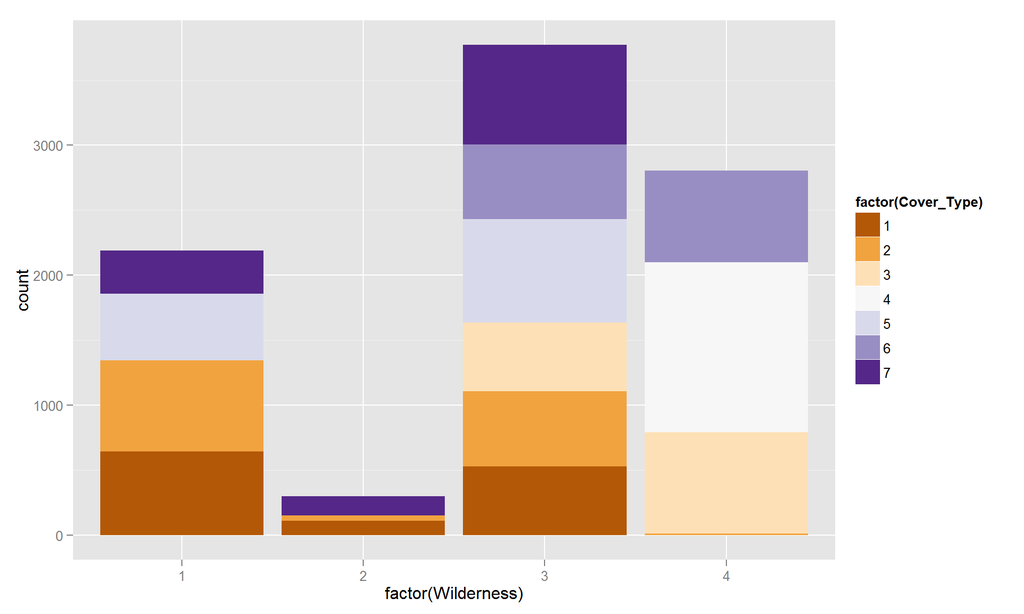

```r
# basic bar chart
qplot(factor(Wilderness), data = wild_long, fill = factor(Cover_Type)) +
  scale_fill_brewer(palette = "PuOr")
```

[dimple](http://dimplejs.org/) is a JavaScript plotting library that’s powered by [d3](http://d3js.org/). Kenton Russell [put a ton of work](http://timelyportfolio.github.io/rCharts_dimple/dimple_timeseries.html) into allowing R users to use dimple. He recently put together the [rcdimple package](https://github.com/timelyportfolio/rcdimple) and I’m testing it here.

```r
# using rcdimple
library(rcdimple)
wild_long %>%
  group_by(Cover_Type, Wilderness) %>%
  summarise(num = n()) %>%
  ungroup() %>%
  dimple(
    x = "Wilderness",
    y = "num",
    groups = "Cover_Type",
    type = "bar",
    data = .
  ) %>%
  rcdimple::add_legend(x = 2, width = 300)  ## can get confused with ggvis package
```

[interactive chart not shown]

I like this plot way better then the ggplot version, and I haven’t played with the parameters much.

- It looks like green and purple (covers 3 and 6) go together
- Orange (cover 4) only occurs in Wilderness 4. Interesting…
- Wilderness 2 is pretty rare
- We should check with Terrill or some ecology guy who could tell us about this

## Elevation by Wilderness

I use the rbokeh package to visualize elevation and wilderness vs cover. This package is an interface to the [bokeh](http://bokeh.pydata.org/en/latest/) visualization library that is really nice.

Here, we really start to see some interesting patterns.

1. First of all, elevation is really strongly related to wilderness type. 2500 meters appears to be an interesting cutoff. It is basically the boundary line for wilderness type 4. Almost all type 4 wilderness occurs below 2500 meters (about 98% of the time), and other wilderness types occur below 2500 meters only rarely. At 2500 meters, wilderness transitions to type 3. Types 1 and 2 typically occur above 2700 meters, though there are some cover type 5 trees in wilderness 1 at about 2500 meters.

```r
wild_bokeh <- wild_long %>%
  mutate(Wilderness = as.character(Wilderness),
         Cover_Type = Cover_Type + runif(n(), -.1, .1))

library(rbokeh)
p <- figure() %>%
  ly_points(Elevation, Cover_Type, data = wild_bokeh,
            glyph = Wilderness, color = Wilderness, alpha = 0.5,
            hover = list(Elevation, Wilderness, Cover_Type))
p
```

[output not shown]

As for predicting cover type, we almost certainly know that if it’s below 2500 meters it is type 3, 4, or 6. Cover type 7 clearly likes high elevation. Beyond that, I’m not sure what information this provides.

## Scatterplot Matrix

Let’s try a scatterplot matrix of the quantitative variables just for fun. This is using the imageR htmlwidget. Click on the plot below to zoom in.

On their own, I don’t know that any of these variables other than elevation appears that interesting right off the bat.

```r
library(imageR)
library(htmltools)
library(base64enc)

# make a tempfile to hold our chart
tf <- tempfile()
# delete our tempfile on exit
on.exit(unlink(tf))

# save our chart as a big png
png(tf, height = 800, width = 1000)
  # make a kind of pretty chart
dat %>%
  select(Elevation:Horizontal_Distance_To_Fire_Points, Cover_Type) %>%
  pairs(., main="Example from ?pairs")
dev.off()
```

png 2

```r
intense(
  tags$img(
    style="height:400px;overflow:hidden;",
    src = dataURI(file=tf,mime="image/png")
  ),
  height = 800
)
```

[interactive chart not shown]

## Cover 1 vs 2

It sounds like our models are having trouble separating Cover 1 and 2. Let’s try and find some differences.

In this plot, size is proportional to the number of points in each group. It appears that in wilderness 2, cover type 1 tends to have a much higher aspect. There are no species of cover type 1 in wilderness 4, but there are some cover type 2 there.

```r
wild_long %>%
  group_by(Cover_Type, Wilderness) %>%
  summarise(Aspect = mean(Aspect),
            num = n()) %>%
  ungroup() %>%
  dimple(y = "Aspect",
         x = c("Wilderness", "Cover_Type"),
         z = "num",
         groups = "Cover_Type",
         data = .,
         type = "bubble") %>%
  add_legend()
```

[interactive chart not shown]

In wilderness 1 and 3, it looks as though Cover Type 1 might have slightly higher elevations.

```r
wild_long %>%
  group_by(Cover_Type, Wilderness) %>%
  summarise(Elevation = mean(Elevation),
            num = n()) %>%
  ungroup() %>%
  dimple(y = "Elevation",
       x = c("Wilderness", "Cover_Type"),
       z = "num",
       groups = "Cover_Type",
       data = .,
       type = "bubble") %>%
  add_legend() %>%
  xAxis(type = "addCategoryAxis")
```

[interactive chart not shown]

## Other Plots

I’m out of ideas for tonight, but let me know what other plots you think might be useful for this example.